# OGIS勉強会

#### 2022年3月29日

エイドリアン  
AIField  
AMBL株式会社

# 自己紹介

本名：Tam Ka Yeung Adrian

出身：ニュージーランド

経歴：教育委員会２年→エンジニア２年

### ポイント

## EDA ＆ XAI

簡単なEDAと前処理を紹介し、XAIについてシェアする。

# データセット

KaggleのTitanic

[figure not shown]

```python
Image(filename='fig/kaggle_titanic.png')
```

## 概要

タイタニックでは、約900名分の乗客のデータが与えられますが、それぞれの乗客の属性（年齢、性別など）が入っています。一部欠損値がありますので、それらを補完しながら、データが与えられていない乗客に対して、生存しているか、生存していないかを判別するモデルを作るというものです。

## データの確認

まずはデータについて確認する。  
【項目】

1. 生値
2. 型
3. 欠損値
4. ユニーク数

```python
# デートの読み込み
train_df = pd.read_csv("data/train.csv")
```

```python
# 生値
display(train_df.head())
```

|  | PassengerId | Survived | Pclass | Name | Sex | Age | SibSp | Parch | Ticket | Fare | Cabin | Embarked |
| --- | --- | --- | --- | --- | --- | --- | --- | --- | --- | --- | --- | --- |
| 0 | 1 | 0 | 3 | Braund, Mr. Owen Harris | male | 22.0 | 1 | 0 | A/5 21171 | 7.2500 | NaN | S |
| 1 | 2 | 1 | 1 | Cumings, Mrs. John Bradley (Florence Briggs Th... | female | 38.0 | 1 | 0 | PC 17599 | 71.2833 | C85 | C |
| 2 | 3 | 1 | 3 | Heikkinen, Miss. Laina | female | 26.0 | 0 | 0 | STON/O2. 3101282 | 7.9250 | NaN | S |
| 3 | 4 | 1 | 1 | Futrelle, Mrs. Jacques Heath (Lily May Peel) | female | 35.0 | 1 | 0 | 113803 | 53.1000 | C123 | S |
| 4 | 5 | 0 | 3 | Allen, Mr. William Henry | male | 35.0 | 0 | 0 | 373450 | 8.0500 | NaN | S |

```python
# データ型
display(train_df.info())
```

```
<class 'pandas.core.frame.DataFrame'>
RangeIndex: 891 entries, 0 to 890
Data columns (total 12 columns):
 #   Column       Non-Null Count  Dtype
---  ------       --------------  -----
 0   PassengerId  891 non-null    int64
 1   Survived     891 non-null    int64
 2   Pclass       891 non-null    int64
 3   Name         891 non-null    object
 4   Sex          891 non-null    object
 5   Age          714 non-null    float64
 6   SibSp        891 non-null    int64
 7   Parch        891 non-null    int64
 8   Ticket       891 non-null    object
 9   Fare         891 non-null    float64
 10  Cabin        204 non-null    object
 11  Embarked     889 non-null    object
dtypes: float64(2), int64(5), object(5)
memory usage: 83.7+ KB
```

```
None
```

```python
# 欠損値
display(pd.isna(train_df).sum())
```

```
PassengerId      0
Survived         0
Pclass           0
Name             0
Sex              0
Age            177
SibSp            0
Parch            0
Ticket           0
Fare             0
Cabin          687
Embarked         2
dtype: int64
```

```python
# ユニーク数
display(train_df.nunique())
```

```
PassengerId    891
Survived         2
Pclass           3
Name           891
Sex              2
Age             88
SibSp            7
Parch            7
Ticket         681
Fare           248
Cabin          147
Embarked         3
dtype: int64
```

## データ型の変換

機械学習を行うため、文字列のものを数値へ変換する。

```python
# SexとEmbarkedのユニーク値を確認する
for col in ["Sex", "Embarked"]:
    print(f"{col}:\t{train_df[col].unique()}")
```

```
Sex:	['male' 'female']
Embarked:	['S' 'C' 'Q' nan]
```

```python
# それぞれの値を数値へ変更
train_df["Embarked"] = train_df["Embarked"].map({"Q":0, "S":1, "C":2})
train_df["Sex"] = train_df["Sex"].map({"male":0, "female":1})
display(train_df.info())
```

```
<class 'pandas.core.frame.DataFrame'>
RangeIndex: 891 entries, 0 to 890
Data columns (total 12 columns):
 #   Column       Non-Null Count  Dtype
---  ------       --------------  -----
 0   PassengerId  891 non-null    int64
 1   Survived     891 non-null    int64
 2   Pclass       891 non-null    int64
 3   Name         891 non-null    object
 4   Sex          891 non-null    int64
 5   Age          714 non-null    float64
 6   SibSp        891 non-null    int64
 7   Parch        891 non-null    int64
 8   Ticket       891 non-null    object
 9   Fare         891 non-null    float64
 10  Cabin        204 non-null    object
 11  Embarked     889 non-null    float64
dtypes: float64(3), int64(6), object(3)
memory usage: 83.7+ KB
```

```
None
```

## 欠損値の処理

欠損データをダミーデータに入れ替える。

```python
# ここでは"median"の値に入れ替えるが、実際は様々な手法があり、
# ケース毎に判断する必要がある
train_df["Age"] = train_df["Age"].fillna(train_df["Age"].median())
train_df["Embarked"] = train_df["Embarked"].fillna(train_df["Embarked"].median())
train_df.isnull().any()
```

```
PassengerId    False
Survived       False
Pclass         False
Name           False
Sex            False
Age            False
SibSp          False
Parch          False
Ticket         False
Fare           False
Cabin           True
Embarked       False
dtype: bool
```

## 説明・目的変数の定義

Dataframeから説明変数（X）と目的変数（Y）を抽出する。

### 仮説

1. 性別が一番影響するのでは？
2. チケットクラス（Pclass）が次に影響するので？

```python
# 目的変数と必要なさそうなデータを除外
X = train_df.drop(["Survived","Cabin", "Ticket", "Name", "PassengerId"], axis=1)
X.info()
```

```
<class 'pandas.core.frame.DataFrame'>
RangeIndex: 891 entries, 0 to 890
Data columns (total 7 columns):
 #   Column    Non-Null Count  Dtype
---  ------    --------------  -----
 0   Pclass    891 non-null    int64
 1   Sex       891 non-null    int64
 2   Age       891 non-null    float64
 3   SibSp     891 non-null    int64
 4   Parch     891 non-null    int64
 5   Fare      891 non-null    float64
 6   Embarked  891 non-null    float64
dtypes: float64(3), int64(4)
memory usage: 48.9 KB
```

```python
# 目的変数を抽出
y = train_df["Survived"]
y.shape
```

```
(891,)
```

```python
# Shapeの確認
display(y.shape, X.shape)
```

```
(891,)
```

```
(891, 7)
```

## Train & Test

訓練用データセットとテスト用データセットの２つに分ける。

```python
X_train, X_test, y_train, y_test = train_test_split(X,y, test_size=0.3, random_state=329)
print("X_train: ", X_train.shape)
print("y_train: ", y_train.shape)
print("X_test:  ", X_test.shape)
print("y_test:  ", y_test.shape)
```

```
X_train:  (623, 7)
y_train:  (623,)
X_test:   (268, 7)
y_test:   (268,)
```

## モデル生成

```python
# モデル生成およびパラメータ確認
RFC = RandomForestClassifier()
display(RFC.get_params())
```

```
{'bootstrap': True,
 'ccp_alpha': 0.0,
 'class_weight': None,
 'criterion': 'gini',
 'max_depth': None,
 'max_features': 'auto',
 'max_leaf_nodes': None,
 'max_samples': None,
 'min_impurity_decrease': 0.0,
 'min_samples_leaf': 1,
 'min_samples_split': 2,
 'min_weight_fraction_leaf': 0.0,
 'n_estimators': 100,
 'n_jobs': None,
 'oob_score': False,
 'random_state': None,
 'verbose': 0,
 'warm_start': False}
```

```python
# 学習を行う
RFC.fit(X_train, y_train)
```

```
RandomForestClassifier()
```

```python
# テストデータに対して予測を行う
y_pred = RFC.predict(X_test)
y_pred_prob = RFC.predict_proba(X_test)[:,1]
```

```python
# 簡易的な評価
metrics.accuracy_score(y_test, y_pred)
```

```
0.8246268656716418
```

# SHAPについて

シャープレイ値（SHAP）とは、ゲーム理論に基づいた、XAIに属する手法である。

```python
# SHAPの定義～SHAP値の算出
exp=shap.TreeExplainer(RFC)
sv_test = exp.shap_values(X_test)
# sv_testは[負と予測する方向への寄与の平均、正と予測方向への寄与の平均]
sv_test = sv_test[1]
sv_test.shape
```

```
(268, 7)
```

```python
# 0行目の特徴量の寄与
sv_test[0]
```

```
array([-0.21554085,  0.15797407, -0.05154905, -0.12162211, -0.08055414,
       -0.02208357, -0.03790847])
```

```python
# SHAPの一致性
exp.expected_value[1] + sv_test[0].sum(), y_pred_prob[0]
```

```
(0.019999999999999574, 0.02)
```

# SHAPを用いたXAI

Shap値を用いてモデルを説明する。

[figure not shown]

```python
# 単体の説明
i = 21
shap.force_plot(exp.expected_value[1], sv_test[0], X_test.iloc[i], matplotlib=True)
```

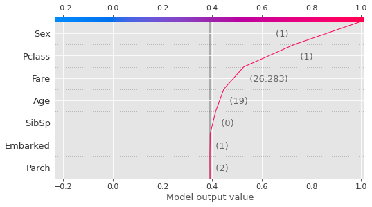

```python
# 全ての特徴量の影響
shap.decision_plot(exp.expected_value[1], sv_test[i], X_test.iloc[i])
```

```
None
```

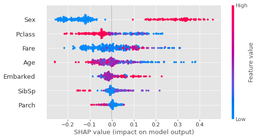

```python
# 全体の特徴量
fig = shap.summary_plot(sv_test, X_test, show=False)
display(fig)
```

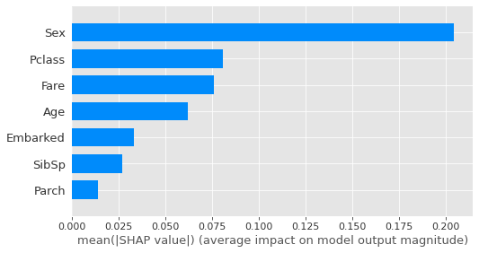

```python
# RFモデルにおける全ての特徴量の影響の寄与
fig = shap.summary_plot(sv_test, X_test, plot_type="bar", show=False)
plt.savefig("fig/summary_bar.png")
```

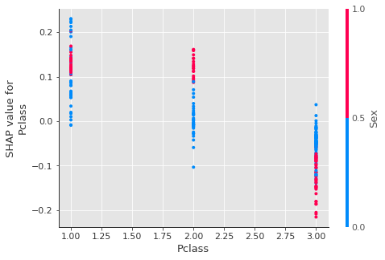

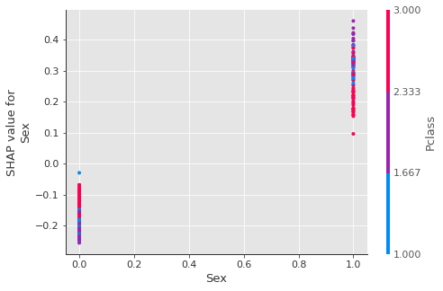

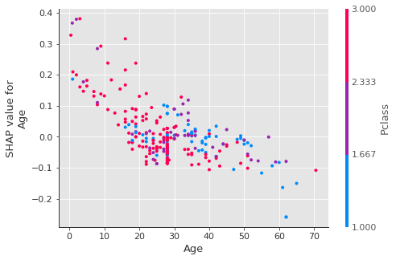

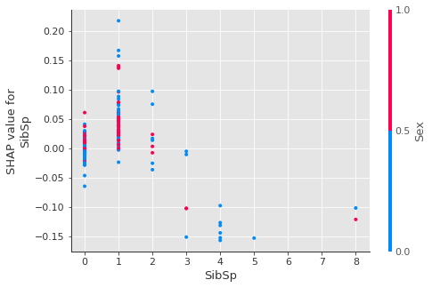

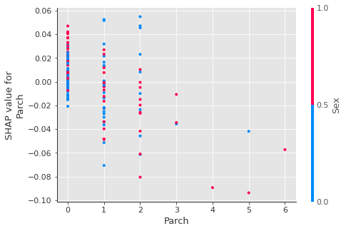

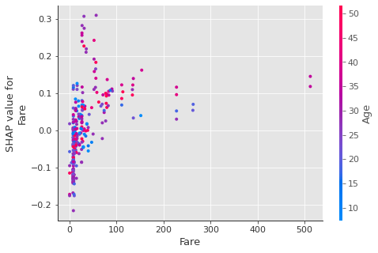

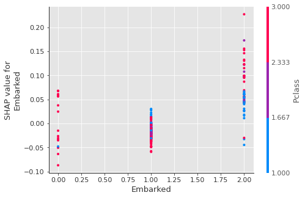

```python
# 特徴量毎の影響
feat_list = X_test.columns

for idx, v in enumerate(feat_list):
    fig = shap.dependence_plot(v, sv_test, X_test, show=False)
    plt.savefig(f"fig/depend_{v}.png")
```

## 振り返り

1. データの確認
2. 前処理
3. 仮説を立てる
4. モデルの学習
5. 結果の説明
6. 繰り返す

# ありがとうございました。